# Calculator

Вадим Хайтов

11 марта 2019 г

Я полный дебил!!!!

Впрочем, вы тоже…

(Это был эпиграф.)

```r
library(lme4)
library(ggplot2)
library(reshape2)
library(sjstats)
library(dplyr)
library(car)
library(doBy)
library(pROC)
library(betareg)
library(knitr)




myt <- read.table("data_salinity3.csv", header = T, sep = ";")

myt$Sp [myt$str > 0.5] <- "M.trossulus" #Лучше обозначать так!
myt$Sp [myt$str <= 0.5] <- "M.edulis"
myt$Sp <- factor(myt$Sp)

# Оставляем только мидий, у которых есть оценка морфотипа
myt2 <- myt[!is.na(myt$ind), ]


# Вводим обозначения для морфотипов
myt2$morph <- ifelse(myt2$ind == 1, "T_m", "E_m")
myt2$morph <- factor(myt2$morph)

#Оставляем только данные, на основе, которых строится модель
myt3 <- myt2[myt2$dataset == "testing", ]
myt2 <- myt2[myt2$dataset == "training", ]


myt2$congr <- ifelse((myt2$ind == 1 & myt2$Sp == "M.trossulus") | (myt2$ind == 0 & myt2$Sp == "M.edulis"), 1, 0   )


# Частота M.trossulus в популяции, вычисленная как срденее значение structure
freq_MT <- summaryBy( str ~ pop, data = myt2)
names(freq_MT) <- c("pop", "freq_MT")

myt2 <- merge(myt2, freq_MT)

myt2$Sp2 <- ifelse(myt2$Sp == "M.trossulus", 1, 0)

myt2$Location <- paste(myt2$sea,"_", myt2$sal_place, sep = "") #Перемменная для кодирования четырех выделов



# Регрессионная модель, описывающая связь между долей Т-морфотипа вероятностью встретить M.trossulus в популяции


prop_T_MT <- summaryBy(Sp2 + ind  ~ pop + sea + sal_place, data = myt2, keep.names = T)
names(prop_T_MT)[4:5] <- c("Prop_MT", "Prop_T")

prop_T_MT$Prop_MT_adj <- ifelse(prop_T_MT$Prop_MT == 0, 0.000001, prop_T_MT$Prop_MT)


prop_T <- summaryBy(ind  ~ pop, data = myt2, keep.names = T)
names(prop_T) <- c("pop", "Prop_T")

myt4 <- merge(myt2, prop_T, by = "pop")

Model_T_MT <- betareg(Prop_MT_adj ~ Prop_T + sea*sal_place, data = prop_T_MT)


new_data <- prop_T_MT %>% group_by(sea, sal_place) %>% do(data.frame(Prop_T = seq(min(.$Prop_T), max(.$Prop_T), length.out = 100)))


predicted <- predict(Model_T_MT, newdata = new_data,  type="response")

new_data$fit <- predicted

# new_data$se <- predicted$se.fit

#
#
#
# ggplot(data = new_data, aes(x = Prop_T)) + geom_line(aes(y = fit, color = sal_place, linetype = sea), size = 1) + theme_bw() + geom_point(data = prop_T_MT, aes(x = Prop_T, y = Prop_MT, color = sal_place, shape = sea), size = 4) + labs(x = "Proportion of T-morphotype in population", y = "Proportion of M.trossulus", color = "Freshness")
#
```

## Немного теории веротяностей

Для описания наших выделов мы можем использовать очень много различных показателей. Все они сведены в таблицу, приведенную ниже. Для начала дадим им расшифровку. Вот их перечень.

- Вероятность встретить M,trossulus среди Т морфотипа. Это оценка условной вероятности $P_{MT|T}$. В таблице – `P_MT_T`
- Вероятность встретить M.edulis среди E морфотипа. Это оценка условной вероятности $P_{ME|E}$. В таблице – `P_ME_E`
- Вероятность встретить M.trossulus среди E морфотипа. Это оценка условной вероятности $P_{MT|E}$. В таблице – `P_MT_E`
- Вероятность встретить M.edulis среди T морфотипа. Это оценка условной вероятности $P_{ME|T}$. В таблице – `P_ME_T`
- Вероятность встретить T морфотип среди M.trossulus. Это оценка условной вероятности $P_{T|MT}$. В таблице – `P_T_MT`
- Вероятность встретить E морфотип среди M.trossulus. Это оценка условной вероятности $P_{E|MT}$. В таблице – `P_E_MT`
- Вероятность встретить T морфотип среди M.edulis. Это оценка условной вероятности $P_{T|ME}$. В таблице – `P_T_ME`
- Вероятность встретить E морфотип среди M.edlis. Это оценка условной вероятности $P_{E|ME}$. В таблице – `P_E_ME`
- Вероятность встретить M.trossulus любого морфотипа. Вероятность события $P_{MT}$. В таблице – `P_MT`
- Вероятность встретить M.edulis любого морфотипа. Вероятность события $P_{ME}$. В таблице – `P_MT`
- Вероятность встретить M.trossulus c T морфотипом. **At!** Не путать с `P_MT_T` или `P_T_MT`. Это вероятность события $P_{MT of T}$. В таблице `P_MT_of_T`
- Вероятность встретить M.trossulus E морфотипа. **At!** Не путать с `P_MT_E` или `P_E_MT`. Это вероятность события $P_{MT of E}$. В таблице `P_MT_of_E`
- Вероятность встретить M.edulis T морфотипа. Аналогично предыдущему. В таблице `P_ME_of_T`
- Вероятность встретить M.edulis E морфотипа. Аналогично предыдущему. В таблице `P_ME_of_E`
- Вероятность встретить E морфотип. Это вероятность события $P_{E}$. В таблице `P_E`
- Вероятность встретить T морфотип. Это вероятность события $P_{T}$. В таблице `P_T`.

### Собственно таблица

```r
probs_calc_3 <- function(variable = "Location", place = "white_normal", P_MT = 0.5) {
  n <- which(names(myt2) == variable)
  d <- myt2[myt2[,n] == place, ]
  dd <- melt(table(d$Sp, d$morph))
  freq_dd <- dcast(data = dd, formula = Var2 ~ Var1)

  P_T_MT <- round(with(data = freq_dd, M.trossulus[2] /(M.trossulus[2] + M.trossulus[1])), 2)
  P_T_ME <- round(with(data = freq_dd, M.edulis[2] /(M.edulis[2] + M.edulis[1])), 2)
  # P_ME <- round(with(data = freq_dd, sum(M.edulis) /(sum(freq_dd[,-1]))), 2)

  P_E_ME <- round(with(data = freq_dd, M.edulis[1] /(M.edulis[1] + M.edulis[2])), 2)
  P_E_MT <- round(with(data = freq_dd, M.trossulus[1] /(M.trossulus[1] + M.trossulus[2])), 2)
  # P_MT <- round(with(data = freq_dd, sum(M.trossulus) /(sum(freq_dd[,-1]))), 2)


  P_MT_T <- (P_T_MT*P_MT)/(P_T_MT*P_MT + P_T_ME*(1-P_MT))
  P_ME_E <- (P_E_ME*(1-P_MT))/(P_E_ME*(1-P_MT) + P_E_MT*P_MT)

  c(P_MT_T, P_ME_E)
}



freq_calc2 <- function(variable = "Location", place = "barents_fresh"){
  n <- which(names(myt2) == variable)
  d <- myt2[myt2[,n] == place, ]
  dd <- melt(table(d$Sp, d$morph))
  freq_dd <- dcast(data = dd, formula = Var2 ~ Var1)

  #Вероятность встретить M,trossulus среди Т морфотипа оценка условной веротяности P_MT|T
  P_MT_T <- freq_dd$M.trossulus[2]/(freq_dd$M.trossulus[2] + freq_dd$M.edulis[2])

  #Вероятность встретить M.edulis среди E морфотипа
  P_ME_E <- freq_dd$M.edulis[1]/(freq_dd$M.edulis[1] + freq_dd$M.trossulus[1])

  #Вероятность встретить M.trossulus среди E морфотипа
  P_MT_E <- freq_dd$M.trossulus[1]/(freq_dd$M.edulis[1] + freq_dd$M.trossulus[1])

  #Вероятность встретить M.edulis среди T морфотипа
  P_ME_T <- freq_dd$M.edulis[2]/(freq_dd$M.edulis[2] + freq_dd$M.trossulus[2])

  #Вероятность встретить T морфотп среди M.trossulus морфотипа
  P_T_MT <- freq_dd$M.trossulus[2]/(freq_dd$M.trossulus[2] + freq_dd$M.trossulus[1])

  #Вероятность встретить E морфотп среди M.trossulus морфотипа
  P_E_MT <- freq_dd$M.trossulus[1]/(freq_dd$M.trossulus[2] + freq_dd$M.trossulus[1])

  #Вероятность встретить T морфотп среди M.edulis
  P_T_ME <- freq_dd$M.edulis[2]/(freq_dd$M.edulis[2] + freq_dd$M.edulis[1])

  #Вероятность встретить E морфотп среди M.edlis
  P_E_ME <- freq_dd$M.edulis[1]/(freq_dd$M.edulis[2] + freq_dd$M.edulis[1])

  #Вероятность встретить M.trossulus любого морфотипа
  P_MT   <- sum(freq_dd$M.trossulus)/(sum(freq_dd$M.trossulus) + sum(freq_dd$M.edulis))

  #Вероятность встретить M.edulis любого морфотипа
  P_ME   <- sum(freq_dd$M.edulis)/(sum(freq_dd$M.trossulus) + sum(freq_dd$M.edulis))

  #Вероятность встретить M.trossulus T морфотипа
  P_MT_of_T   <- (freq_dd$M.trossulus[2])/(sum(freq_dd$M.trossulus) + sum(freq_dd$M.edulis))

  #Вероятность встретить M.trossulus E морфотипа
  P_MT_of_E   <- (freq_dd$M.trossulus[1])/(sum(freq_dd$M.trossulus) + sum(freq_dd$M.edulis))

  #Вероятность встретить M.edulis T морфотипа
  P_ME_of_T   <- (freq_dd$M.edulis[2])/(sum(freq_dd$M.trossulus) + sum(freq_dd$M.edulis))

  #Вероятность встретить M.edulis E морфотипа
  P_ME_of_E   <- (freq_dd$M.edulis[1])/(sum(freq_dd$M.trossulus) + sum(freq_dd$M.edulis))

  #Вероятность встретить  E морфотип
  P_E   <- sum(freq_dd[1, -1])/sum(freq_dd[,-1])

  #Вероятность встретить  T морфотип
  P_T   <- sum(freq_dd[2, -1])/sum(freq_dd[,-1])


  props <- c(P_MT_T, P_ME_E, P_MT_E, P_ME_T, P_T_MT, P_E_MT, P_T_ME,  P_E_ME, P_MT, P_ME, P_MT_of_T, P_MT_of_E, P_ME_of_T, P_ME_of_E, P_E, P_T)

  names(props) <- c("P_MT_T", "P_ME_E", "P_MT_E", "P_ME_T", "P_T_MT", "P_E_MT", "P_T_ME",  "P_E_ME", "P_MT", "P_ME", "P_MT_of_T", "P_MT_of_E", "P_ME_of_T", "P_ME_of_E", "P_E", "P_T")

  props
}


All_freq <- data.frame(barents_normal = freq_calc2(place = "barents_normal"),
                       barents_fresh = freq_calc2(place = "barents_fresh"),
                       white_normal = freq_calc2(place = "white_normal"),
                       white_fresh = freq_calc2(place = "white_fresh"))
kable(All_freq)
```

|  | barents_normal | barents_fresh | white_normal | white_fresh |
| --- | --- | --- | --- | --- |
| P_MT_T | 0.5408163 | 0.8742857 | 0.7692308 | 0.9112903 |
| P_ME_E | 0.7103825 | 0.7510549 | 0.8984911 | 0.5952381 |
| P_MT_E | 0.2896175 | 0.2489451 | 0.1015089 | 0.4047619 |
| P_ME_T | 0.4591837 | 0.1257143 | 0.2307692 | 0.0887097 |
| P_T_MT | 0.8333333 | 0.7216981 | 0.6837607 | 0.8692308 |
| P_E_MT | 0.1666667 | 0.2783019 | 0.3162393 | 0.1307692 |
| P_T_ME | 0.6338028 | 0.1100000 | 0.0682788 | 0.3055556 |
| P_E_ME | 0.3661972 | 0.8900000 | 0.9317212 | 0.6944444 |
| P_MT | 0.4725111 | 0.5145631 | 0.2497332 | 0.7831325 |
| P_ME | 0.5274889 | 0.4854369 | 0.7502668 | 0.2168675 |
| P_MT_of_T | 0.3937593 | 0.3713592 | 0.1707577 | 0.6807229 |
| P_MT_of_E | 0.0787519 | 0.1432039 | 0.0789755 | 0.1024096 |
| P_ME_of_T | 0.3343239 | 0.0533981 | 0.0512273 | 0.0662651 |
| P_ME_of_E | 0.1931649 | 0.4320388 | 0.6990395 | 0.1506024 |
| P_E | 0.2719168 | 0.5752427 | 0.7780149 | 0.2530120 |
| P_T | 0.7280832 | 0.4247573 | 0.2219851 | 0.7469880 |

**Внимание! Проверьте, пожалуйста, совпадают ли эти числа с тем, чем оперируете вы. Если нет, то срочно дайте знать.**

## Продолжение про теорию веротяностей

**Здесь читаем очень внмательно и критично** Если я ошибся здесь, то все, что будет в калькуляторе – полная лажа.

Поскольку мидия вида M.trossulus может иметь либо морфотип T, либо морфотип E, то события $MT of T$ и $MT of E$ взаимоисключающие. Следовательно, по теореме о сумме вероятностей, можно написать следующее уравнение.

$$P_{MT} = P_{MT of T} + P_{MT of E}$$

Проверьте по таблице!

По тем же причинам справедливо вот такое выражение

$$P_{T} = P_{MT of T} + P_{ME of T}$$

Тогда, выражая одно через другое, получаем следующее

$$P_{MT of T} = P_{T} - P_{ME of T}$$

Следовательно

$$P_{MT} = P_{T} + (P_{MT of E} - P_{ME of T})$$

Здесь нетрудно увидеть линейную функцию: $P_{MT} = b_0 + b_1 \cdot P_{T}$. При этом $b1 = 1$ (Как и предполагал ППС), но вот $b_0$ точно не равен нулю (о чем говорил ВМХ).

Иным словами вероятность встретить M.trossulus линейно зависит от вероятности встретить T-морфотип, но с некоторой поправкой ($b_0$), равной разнице вероятности встретить мидию вида M.trossulus с E-морфотипом и вероятности встретить мидию вида M.edulis с T-морфотипом.

Биологический смысл этой поправки, как мне видится прост и информативен. Она равна нулю если $P_{MT of E} = P_{ME of T}$. Это будет тогда, когда мы одинаково часто лажаем с определением вида, как по Т-морфотипу, так и по Е-морфотипу. Если $b_0 > 0$, то чаще лажаем в использовании Е-морфотипа, а если $b_0 < 0$, то чаще лажаем в использовании T-морфотипа.

Если в этих рассуждениях нет ошибки, то тогда калькулятор выглядит вот так.

# Калькулятор

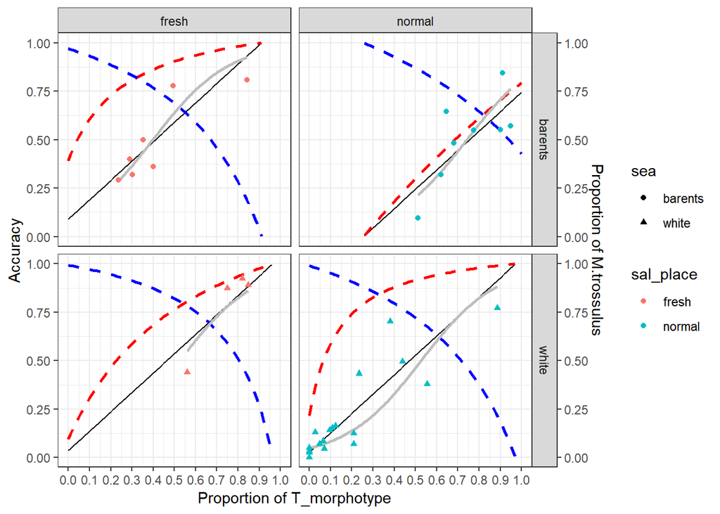

```r
P_MT_calc2 <- function(P_T=0.5, P_MT_of_E, P_ME_of_T){
  P_MT <-P_T + (P_MT_of_E - P_ME_of_T)
  P_MT

}



props <- expand.grid(Prop_T = seq(0, 1, 0.01), sea = c("barents", "white"), sal_place = c("fresh", "normal"))

props$place <- paste(props$sea,"_", props$sal_place, sep = "")


for(i in 1:nrow(props)){
  freq_calc_result <- freq_calc2(place = props$place[i])

  P_MT_of_E <-   freq_calc_result [12]
  P_ME_of_T <-  freq_calc_result [13]

  props$Prop_MT [i] <- P_MT_calc2(P_T = props$Prop_T[i], P_MT_of_E = P_MT_of_E, P_ME_of_T = P_ME_of_T )
  props$P_MT_T [i] <- probs_calc_3(place = props$place[i], P_MT = props$Prop_MT[i])[1]
  props$P_ME_E [i] <- probs_calc_3(place = props$place[i], P_MT = props$Prop_MT[i])[2]
}




(Pl_calc <- ggplot(props, aes(x = Prop_T, y = Prop_MT)) + geom_line(color = "black") + facet_grid(sea~sal_place) + geom_line(aes(y=P_MT_T), color = "red", linetype = 2, size = 1) + geom_line(aes(y=P_ME_E), color = "blue", linetype = 2, size = 1) + geom_line(data = new_data, aes(x = Prop_T, y = fit), color = "gray", size = 1) + labs(x="Proportion of T_morphotype", y = "Accuracy")  + theme_bw() +  scale_x_continuous(breaks = seq(0, 1, 0.1)) + geom_point(data = prop_T_MT, aes(x = Prop_T, y = Prop_MT, color = sal_place, shape = sea))  + scale_y_continuous( sec.axis = sec_axis(trans = ~., name = "Proportion of M.trossulus"), limits = c(0,1) ))
```